# Generalized linear regression: ZIP and ZINB

# 1 Setup

**R**

```r
install.packages("pscl")
install.packages("countreg", repos="http://R-Forge.R-project.org")
install.packages("topmodels", repos="http://R-Forge.R-project.org")
install.packages("distributions3")
install.packages("modelsummary")
install.packages("marginaleffects")
install.packages("rstudioapi")
```

```r
library(MASS) ## glm.nb
library(countreg)
library(pscl)
library(topmodels)
library(modelsummary)
library(boot)
library(marginaleffects)
```

Read in the dataset for the lecture and specify column classes (types).

```r
df <- read.csv("../data/polish-jvs.csv", colClasses = c("character", "factor", rep("character", 4), "numeric"))
head(df)
```

| id | woj | public | size | nace | nace_division | vacancies |
| --- | --- | --- | --- | --- | --- | --- |
| 27350 | 14 | 1 | Large | O | 84 | 2 |
| 26705 | 14 | 1 | Large | O | 84 | 1 |
| 257456 | 24 | 1 | Large | O | 84 | 2 |
| 183657 | 16 | 1 | Medium | O | 84 | 0 |
| 200042 | 18 | 1 | Medium | O | 84 | 0 |
| 26050 | 14 | 1 | Large | R | 91 | 4 |

**Python**

Load modules

```bash
!pip install statsmodels
```

```python
from patsy import dmatrices
import pandas as pd
import numpy as np
import statsmodels.api as sm
import statsmodels.formula.api as smf
```

Read in the dataset for the lecture and specify column classes (types).

```python
df = pd.read_csv("../data/polish-jvs.csv", dtype={"id": np.int64, "woj":str, "public":str,"size": str, "nace_division": str, "nace": str})
df.head()
```

```
       id woj public    size nace nace_division  vacancies
0   27350  14      1   Large    O            84          2
1   26705  14      1   Large    O            84          1
2  257456  24      1   Large    O            84          2
3  183657  16      1  Medium    O            84          0
4  200042  18      1  Medium    O            84          0
```

**Julia**

```julia
using Pkg
Pkg.add(["Effects", "StatsBase", "CSV", "CategoricalArrays", "GLM"])
```

Load packages

```julia
using Effects
using StatsBase
using CSV
using CategoricalArrays
using GLM
using Statistics
using DataFrames
```

Read in the dataset for the lecture and specify column classes (types).

```julia
df=CSV.read("../data/polish-jvs.csv", DataFrame,
            types = Dict(:id => Int64, :woj=> String, :public=> String,
                         :size => String, :nace_division => String, :nace => String));
first(df, 5)
```

# 2 Zero-inflated Poisson (ZIP)

**R**

```r
m1 <- pscl::zeroinfl(formula = vacancies ~ size + public,
                     dist = "poisson",
                     link = "logit",
                     data = df)
```

```r
summary(m1)
```

```
Call:
pscl::zeroinfl(formula = vacancies ~ size + public, data = df, dist = "poisson",
    link = "logit")

Pearson residuals:
     Min       1Q   Median       3Q      Max
 -0.4465  -0.4267  -0.2742  -0.2013 315.3641

Count model coefficients (poisson with log link):
             Estimate Std. Error z value Pr(>|z|)
(Intercept)  2.577663   0.005034  512.04   <2e-16 ***
sizeMedium  -1.438596   0.018330  -78.48   <2e-16 ***
sizeSmall   -2.312757   0.044964  -51.44   <2e-16 ***
public1     -0.580550   0.009439  -61.50   <2e-16 ***

Zero-inflation model coefficients (binomial with logit link):
            Estimate Std. Error z value Pr(>|z|)
(Intercept)  1.52431    0.01958  77.861   <2e-16 ***
sizeMedium   0.76106    0.03290  23.135   <2e-16 ***
sizeSmall    1.08024    0.05176  20.869   <2e-16 ***
public1      0.02671    0.02749   0.971    0.331
---
Signif. codes:  0 '***' 0.001 '**' 0.01 '*' 0.05 '.' 0.1 ' ' 1

Number of iterations in BFGS optimization: 29
Log-likelihood: -8.799e+04 on 8 Df
```

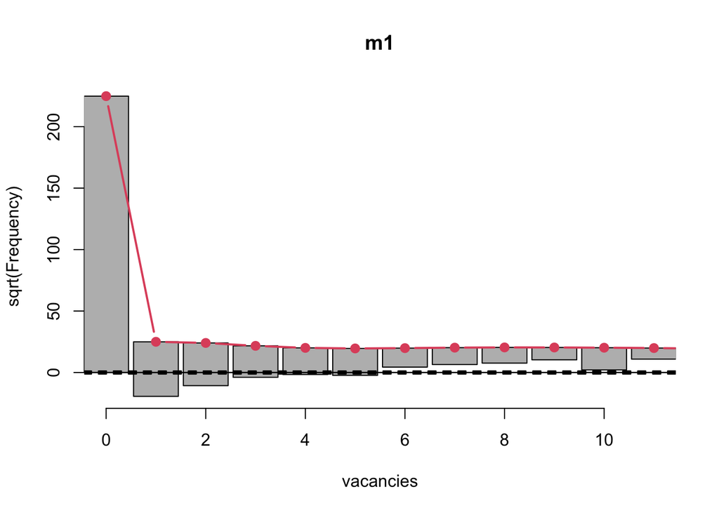

```r
rootogram(m1, plot = "base", xlim = c(0,11))
```

```r
avg_slopes(m1, type = "zero")
```

```
   Term       Contrast Estimate Std. Error      z Pr(>|z|)     S    2.5 %
 public 1 - 0           0.00291    0.00298  0.974     0.33   1.6 -0.00294
 size   Medium - Large  0.08590    0.00333 25.759   <0.001 483.6  0.07936
 size   Small - Large   0.10921    0.00391 27.921   <0.001 567.5  0.10154
  97.5 %
 0.00875
 0.09243
 0.11687

Type:  zero
```

```r
avg_slopes(m1, type = "response")
```

```
   Term       Contrast Estimate Std. Error     z Pr(>|z|)     S  2.5 % 97.5 %
 public 1 - 0            -0.563     0.0231 -24.3   <0.001 432.3 -0.608 -0.518
 size   Medium - Large   -1.737     0.0290 -59.9   <0.001   Inf -1.794 -1.680
 size   Small - Large    -1.904     0.0286 -66.6   <0.001   Inf -1.960 -1.848

Type:  response
```

Interpretation:

- Count Model (Poisson component):
  - Public sector coefficient: exp(-0.580550) ≈ 0.560 – Being a public organization is associated with approximately 44% fewer vacancies compared to private organizations, holding other factors constant.
  - Public sector coefficient (AME): -0.563 – On average, public organizations have 0.563 fewer vacancies than private organizations, holding other variables constant.
- Zero-Inflation Model (logit component):
  - Public sector coefficient: exp(0.02671) ≈ 1.027 – Public organizations have approximately 2.7% higher odds of having zero vacancies compared to private organizations, but this effect is not statistically significant (p = 0.331).
  - Public sector coefficient (AME): 0.00291 – Being a public organization is associated with a 0.291 percentage point increase in the probability of having zero vacancies compared to private organizations.

**Python**

```python
y, x = dmatrices("vacancies ~ size + public", df, return_type='dataframe')
```

```python
m1 = sm.ZeroInflatedPoisson(endog=y, exog=x, exog_infl=x, inflation='logit').fit(maxiter = 100)
```

```
Optimization terminated successfully.
         Current function value: 1.530794
         Iterations: 45
         Function evaluations: 49
         Gradient evaluations: 49
```

```python
print(m1.summary())
```

```
                     ZeroInflatedPoisson Regression Results
===============================================================================
Dep. Variable:               vacancies   No. Observations:                57480
Model:             ZeroInflatedPoisson   Df Residuals:                    57476
Method:                            MLE   Df Model:                            3
Date:                 Mon, 19 May 2025   Pseudo R-squ.:                  0.1086
Time:                         21:43:57   Log-Likelihood:                -87990.
converged:                        True   LL-Null:                       -98710.
Covariance Type:             nonrobust   LLR p-value:                     0.000
==========================================================================================
                             coef    std err          z      P>|z|      [0.025      0.975]
------------------------------------------------------------------------------------------
inflate_Intercept          1.5243      0.020     77.895      0.000       1.486       1.563
inflate_size[T.Medium]     0.7612      0.033     23.343      0.000       0.697       0.825
inflate_size[T.Small]      1.0801      0.045     23.743      0.000       0.991       1.169
inflate_public[T.1]        0.0266      0.027      0.970      0.332      -0.027       0.080
Intercept                  2.5777      0.005    512.165      0.000       2.568       2.588
size[T.Medium]            -1.4386      0.018    -79.328      0.000      -1.474      -1.403
size[T.Small]             -2.3126      0.039    -59.510      0.000      -2.389      -2.236
public[T.1]               -0.5805      0.009    -61.561      0.000      -0.599      -0.562
==========================================================================================
```

**Julia**

# 3 Zero-inflated Negative Binomial (ZINB)

**R**

```r
m2 <- pscl::zeroinfl(formula = vacancies ~ size + public,
                     dist = "negbin",
                     link = "logit",
                     data = df)
```

```r
summary(m2)
```

```
Call:
pscl::zeroinfl(formula = vacancies ~ size + public, data = df, dist = "negbin",
    link = "logit")

Pearson residuals:
     Min       1Q   Median       3Q      Max
 -0.2441  -0.2302  -0.1966  -0.1638 240.3514

Count model coefficients (negbin with log link):
            Estimate Std. Error z value Pr(>|z|)
(Intercept)  1.03702    0.04171   24.86   <2e-16 ***
sizeMedium  -2.02882    0.05190  -39.09   <2e-16 ***
sizeSmall   -3.02880    0.07662  -39.53   <2e-16 ***
public1     -0.83745    0.04916  -17.04   <2e-16 ***
Log(theta)  -2.77024    0.02514 -110.18   <2e-16 ***

Zero-inflation model coefficients (binomial with logit link):
            Estimate Std. Error z value Pr(>|z|)
(Intercept)  -1.9130     0.2202  -8.688  < 2e-16 ***
sizeMedium    0.9103     0.2126   4.282 1.85e-05 ***
sizeSmall     1.3595     0.2393   5.681 1.34e-08 ***
public1     -12.9727   119.8795  -0.108    0.914
---
Signif. codes:  0 '***' 0.001 '**' 0.01 '*' 0.05 '.' 0.1 ' ' 1

Theta = 0.0626
Number of iterations in BFGS optimization: 66
Log-likelihood: -3.854e+04 on 9 Df
```

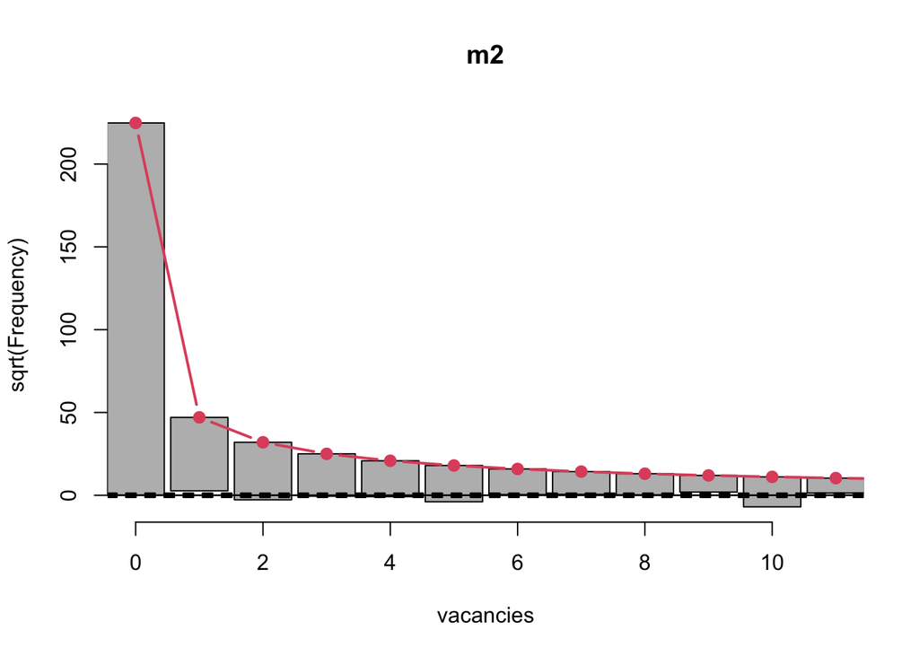

```r
rootogram(m2, plot = "base", xlim = c(0,11))
```

```r
BIC(m1, m2)
```

|  | df | BIC |
| --- | --- | --- |
| m1 | 8 | 176067.72 |
| m2 | 9 | 77172.36 |

**Exercise**:

- run poisson regression with the same set of variables
- run NB regression with the same set of variables
- which model we should use? PO, NB, ZIP or ZINB regression? Why? Justify

**Python**

```python
m2 = sm.ZeroInflatedNegativeBinomialP(endog=y, exog=x, exog_infl=x, inflation='logit').fit(maxiter = 500)
```

```
Optimization terminated successfully.
         Current function value: 0.670440
         Iterations: 112
         Function evaluations: 118
         Gradient evaluations: 118
```

```python
print(m2.summary())
```

```
                     ZeroInflatedNegativeBinomialP Regression Results
=========================================================================================
Dep. Variable:                         vacancies   No. Observations:                57480
Model:             ZeroInflatedNegativeBinomialP   Df Residuals:                    57476
Method:                                      MLE   Df Model:                            3
Date:                           Mon, 19 May 2025   Pseudo R-squ.:                 0.04389
Time:                                   21:44:33   Log-Likelihood:                -38537.
converged:                                  True   LL-Null:                       -40306.
Covariance Type:                       nonrobust   LLR p-value:                     0.000
==========================================================================================
                             coef    std err          z      P>|z|      [0.025      0.975]
------------------------------------------------------------------------------------------
inflate_Intercept         -1.9119      0.220     -8.692      0.000      -2.343      -1.481
inflate_size[T.Medium]     0.9098      0.212      4.284      0.000       0.494       1.326
inflate_size[T.Small]      1.3588      0.239      5.682      0.000       0.890       1.827
inflate_public[T.1]       -9.3071     19.184     -0.485      0.628     -46.906      28.292
Intercept                  1.0371      0.042     24.864      0.000       0.955       1.119
size[T.Medium]            -2.0288      0.052    -39.089      0.000      -2.131      -1.927
size[T.Small]             -3.0288      0.077    -39.529      0.000      -3.179      -2.879
public[T.1]               -0.8376      0.049    -17.040      0.000      -0.934      -0.741
alpha                     15.9601      0.401     39.773      0.000      15.174      16.747
==========================================================================================
```

**Julia**